# Exercise Activity Evaluation Analysis

This is an analysis of data collected to test the ability to classify the quality of activity performance. Links to the original data and a paper describing the experiment can be found at http://groupware.les.inf.puc-rio.br/har.

## Exploring and Pre-processing the Data

A subset of the data was made available to the class for training and testing as well as a small set of data to submit predictions for grading. The first step was to load the data and take a look.

```r
rawdata<-read.csv("pml-training.csv",head=TRUE)
analysisdata<-rawdata[,-grep("kurtosis|skewness|max|min|avg|stddev|var|amplitude|X|window|user|timestamp",names(rawdata))]
```

Many of the fields have a majority of blanks or NA Values. They correspond to statistics such as mean and standard deviations calculated over varying time windows. These values will not be very useful for the predictions of classe, there are very few actual values and the data to evaluate for grading do not have any values for these fields. The user and time stamp data will not be useful either since the quality of exercise should not be related to the actual user per se or to the absolute time of the data. The time stamps could be useful for the relating the various observations, but again the data for submission is not sufficient to create time window statistics so all of these fields have been removed.

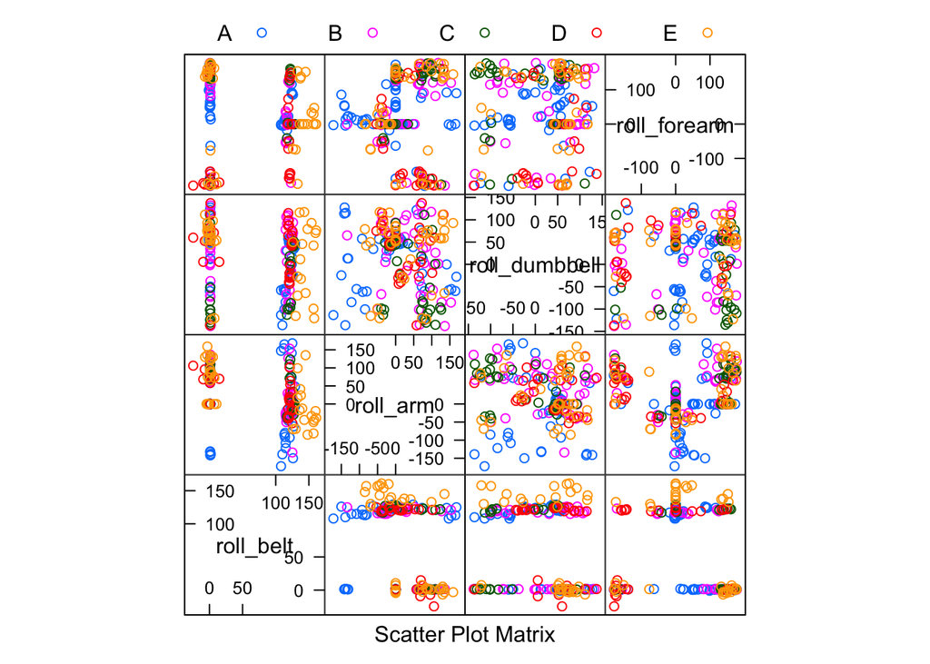

```r
library(caret,quietly=TRUE)
split<-.1
set.seed(203289)
inBuild<- createDataPartition(y=analysisdata$classe,p=split,list=FALSE)
validation<- analysisdata[-inBuild,]
builddata<-analysisdata[inBuild,]
inTrain<-createDataPartition(y=builddata$classe,p=split,list=FALSE)
training<-builddata[inTrain,]
testing<-builddata[-inTrain,]
classeIndex<-grep("classe",names(training))
#Figure 1
featurePlot(training[,seq(1,classeIndex-1,13)],y=training$classe,plot="pairs",auto.key = list(columns = 5))
```

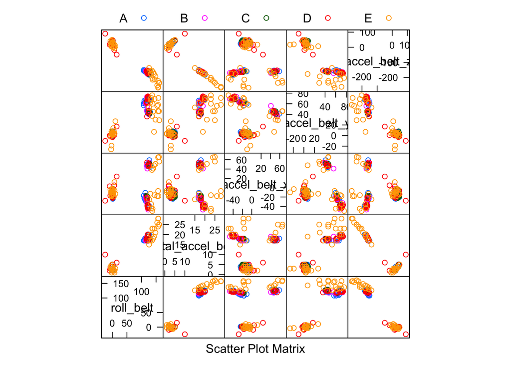

```r
corMat<-abs(cor(training[,-classeIndex]))
diag(corMat) = 0
highCor<-which(corMat>0.9, arr.ind=T)
highCor<-highCor[order(highCor[,1]),]
#Figure 2
featurePlot(training[,c(1,4,8:10)],y=training$classe,plot="pairs",auto.key = list(columns = 5))
```

Looking through the featurePlots in pairs in Figure 1, there are a number of predictor combinations that show different structures for different classe values. They do not look even roughly linear however, so a tree algorithm such as random forests is likely to work better and more simply than linear regression models. In Figure 2 it seems that the classe values overlap considerably for the accel predictors and since they are highly correlated (over 90%) with other variables removing them should not hurt the analysis. The gyro predictors are also highly correlated but with each other rather than other predictors.

```r
subSample<-createDataPartition(y=training$classe,p=.2,list=FALSE)
modelFit <- train(training[subSample,]$classe~.,method="rf",data=training[subSample,-classeIndex],prox=TRUE)
important<-varImp(modelFit)$importance
training<-training[,-grep("accel",names(training))]
testing<-testing[,-grep("accel",names(testing))]
validation<-validation[,-grep("accel",names(validation))]
classeIndex<-grep("classe",names(training))
```

```r
#exclude roll_Belt and classe
corMat<-abs(cor(training[,-c(1,classeIndex)]))
diag(corMat) = 0
highCor<-which(corMat>0.5, arr.ind=T)
highCor<-highCor[order(highCor[,1]),]
highCor<-unique(highCor[,1])+1 #take unique indicies and add one since roll_Belt was excluded
preProc <- preProcess(training[,highCor],method="pca",thresh=.95)

trainPC <- predict(preProc,training[,highCor])
training<-training[,-highCor]
training[names(trainPC)]<-trainPC
classeIndex<-grep("classe",names(training))
classeInBack<- c(c(1:dim(training)[2])[-classeIndex],classeIndex)
training<-training[,classeInBack]

testPC <- predict(preProc,testing[,highCor])
testing<-testing[,-highCor]
testing[names(testPC)]<-testPC
testing<-testing[,classeInBack]

valPC <- predict(preProc,validation[,highCor])
validation<-validation[,-highCor]
validation[names(valPC)]<-valPC
validation<-validation[,classeInBack]
```

## Training Models and Applying to Test Data

```r
classeIndex<-grep("classe",names(training))
modelFit <- train(training$classe~.,method="rf",data=training[,-classeIndex],prox=TRUE)
predictions<-predict(modelFit,testing[,-classeIndex])
confusionMatrix(predictions,testing$classe)
```

```
## Confusion Matrix and Statistics
##
##           Reference
## Prediction   A   B   C   D   E
##          A 408  75  64  29  10
##          B  44 168  27  17  21
##          C  15  35 193  53  23
##          D  24  13  16 163  10
##          E  11  51   8  27 260
##
## Overall Statistics
##
##                Accuracy : 0.675
##                  95% CI : (0.653, 0.697)
##     No Information Rate : 0.284
##     P-Value [Acc > NIR] : < 2e-16
##
##                   Kappa : 0.587
##  Mcnemar's Test P-Value : 1.36e-14
##
## Statistics by Class:
##
##                      Class: A Class: B Class: C Class: D Class: E
## Sensitivity             0.813   0.4912    0.627   0.5640    0.802
## Specificity             0.859   0.9234    0.914   0.9573    0.933
## Pos Pred Value          0.696   0.6065    0.605   0.7212    0.728
## Neg Pred Value          0.920   0.8831    0.920   0.9181    0.955
## Prevalence              0.284   0.1938    0.175   0.1637    0.184
## Detection Rate          0.231   0.0952    0.109   0.0924    0.147
## Detection Prevalence    0.332   0.1569    0.181   0.1280    0.202
## Balanced Accuracy       0.836   0.7073    0.770   0.7607    0.868
```

```r
rmI<-c()
vAcc<-confusionMatrix(predictions,testing$classe)$overall[1]

important<-varImp(modelFit)$importance
leastImport<-order(important['Overall'])
bounds<- 3*1:5

for(i in bounds){
     removeIndexes <- -c(leastImport[1:i],classeIndex)
     modelFitNw <- train(training$classe~.,method="rf",data=training[,removeIndexes],prox=TRUE)
     predictions<-predict(modelFitNw,testing[,removeIndexes])
     confusionMatrix(predictions,testing$classe)
     if (confusionMatrix(predictions,testing$classe)$overall[1]>max(vAcc)){
          modelFit<-modelFitNw
          rmI<-removeIndexes
     }
     vAcc<-append(vAcc,confusionMatrix(predictions,testing$classe)$overall[1])
}
vAcc
```

```
## Accuracy Accuracy Accuracy Accuracy Accuracy Accuracy
##   0.6754   0.6714   0.6788   0.6674   0.6697   0.6640
```

```r
i<-which.max(vAcc)
i
```

```
## Accuracy
##        3
```

```r
removeIndexes <- rmI
removeIndexes
```

```
## [1]  -3  -8 -13 -16 -26 -11 -27
```

```r
predictions<-predict(modelFit,testing[,removeIndexes])
confusionMatrix(predictions,testing$classe)
```

```
## Confusion Matrix and Statistics
##
##           Reference
## Prediction   A   B   C   D   E
##          A 401  71  69  32   8
##          B  49 168  15  15  15
##          C  19  38 201  49  26
##          D  24  19  18 163   9
##          E   9  46   5  30 266
##
## Overall Statistics
##
##                Accuracy : 0.679
##                  95% CI : (0.657, 0.701)
##     No Information Rate : 0.284
##     P-Value [Acc > NIR] : <2e-16
##
##                   Kappa : 0.592
##  Mcnemar's Test P-Value : <2e-16
##
## Statistics by Class:
##
##                      Class: A Class: B Class: C Class: D Class: E
## Sensitivity             0.799   0.4912    0.653   0.5640    0.821
## Specificity             0.857   0.9339    0.909   0.9526    0.938
## Pos Pred Value          0.690   0.6412    0.604   0.6996    0.747
## Neg Pred Value          0.915   0.8842    0.925   0.9178    0.959
## Prevalence              0.284   0.1938    0.175   0.1637    0.184
## Detection Rate          0.227   0.0952    0.114   0.0924    0.151
## Detection Prevalence    0.329   0.1484    0.189   0.1320    0.202
## Balanced Accuracy       0.828   0.7126    0.781   0.7583    0.879
```

```r
names(testing[,removeIndexes])
```

```
##  [1] "roll_belt"        "roll_arm"         "roll_dumbbell"
##  [4] "gyros_dumbbell_y" "roll_forearm"     "pitch_forearm"
##  [7] "magnet_forearm_x" "magnet_forearm_y" "PC2"
## [10] "PC4"              "PC5"              "PC7"
## [13] "PC8"              "PC9"              "PC10"
## [16] "PC11"             "PC12"             "PC13"
## [19] "PC14"             "PC15"
```

```r
names(validation[,removeIndexes])
```

```
##  [1] "roll_belt"        "roll_arm"         "roll_dumbbell"
##  [4] "gyros_dumbbell_y" "roll_forearm"     "pitch_forearm"
##  [7] "magnet_forearm_x" "magnet_forearm_y" "PC2"
## [10] "PC4"              "PC5"              "PC7"
## [13] "PC8"              "PC9"              "PC10"
## [16] "PC11"             "PC12"             "PC13"
## [19] "PC14"             "PC15"
```

```r
predictions<-predict(modelFit,validation[,removeIndexes])
confusionMatrix(predictions,validation$classe)
```

```
## Confusion Matrix and Statistics
##
##           Reference
## Prediction    A    B    C    D    E
##          A 4042  729  668  249   67
##          B  391 1646  180  233  149
##          C  167  381 1986  467  278
##          D  302  223  193 1598  127
##          E  120  438   52  347 2625
##
## Overall Statistics
##
##                Accuracy : 0.674
##                  95% CI : (0.667, 0.681)
##     No Information Rate : 0.284
##     P-Value [Acc > NIR] : <2e-16
##
##                   Kappa : 0.585
##  Mcnemar's Test P-Value : <2e-16
##
## Statistics by Class:
##
##                      Class: A Class: B Class: C Class: D Class: E
## Sensitivity             0.805   0.4817    0.645   0.5522    0.809
## Specificity             0.864   0.9331    0.911   0.9428    0.934
## Pos Pred Value          0.702   0.6333    0.606   0.6541    0.733
## Neg Pred Value          0.918   0.8824    0.924   0.9148    0.956
## Prevalence              0.284   0.1935    0.174   0.1639    0.184
## Detection Rate          0.229   0.0932    0.112   0.0905    0.149
## Detection Prevalence    0.326   0.1472    0.186   0.1384    0.203
## Balanced Accuracy       0.835   0.7074    0.778   0.7475    0.871
```